# Maximum likelihood estimator (MLE) in logistic regression

S. Sudhir

2023-08-16

# Optimization for Maximum Likelihood Estimation

## MLE for mean and standard deviation of a random sample from $N(\mu, \sigma)$

Here we’ll use optimization to confirm that, given a simple random sample $X_1, \ldots, X_n \sim N(\mu, \sigma^2)$, the maximum-likelihood estimates for the unknown mean $\mu$ and standard deviation $\sigma$ are

$$\mu = \frac{1}{n} \sum_{i=1}^n
X_i$$

and

$$\sigma = \sqrt{\frac{1}{n} \sum_{i=1}^n
(X_i - \mu)^2}$$

Since each $X_i \sim N(\mu, \sigma^2)$ has the probability density function

$$f(x_i; \mu, \sigma) = \frac{1}{\sqrt{2
\pi} \sigma} \exp\left(-\frac{(x_i - \mu)^2}{2
\sigma^2}\right)$$

```r
## Function for Normal Probability Density Function
norm_pdf = function(x, mean, sd)
{
  return(1/(sqrt(2*pi)*sd) * exp((-1/(2*sd^2))*(x - mean)^2))
}
```

and the $X_i$’s are independent, the density function for the sample is

$$f(x_1, \ldots, x_n; \mu; \sigma) =
\prod_{i=1}^n f(x_i; \mu, \sigma) = \left(\frac{1}{\sqrt{2 \pi}
\sigma}\right)^n \exp\left(-\frac{1}{{2 \sigma^2}} \sum_{i=1}^n (x_i -
\mu)^2\right)$$

If we now consider the sample $(x_1, \ldots, x_n)$ as fixed, then $f(x_1, \ldots, x_n; \mu; \sigma)$ can be regarded as a function of $\mu$ and $\sigma$ called the likelihood, $L$:

$$L(\mu, \sigma; x_1, \ldots, x_n) =
f(x_1, \ldots, x_n; \mu; \sigma)$$

We want to use optimization to find the $(\mu, \sigma)$ pair that maximizes $L(\mu, \sigma; x_1, \ldots, x_n)$. However, computing $L$ is problematic because its product of small numbers often leads to underflow, in which the product is closer to zero than a computer can represent with the usual floating-point arithmetic. Taking logarithms addresses this problem by transforming products of very small positive numbers to sums of moderate negative numbers. For example, $10^{-10}$ is very small, but $\log(10^{-10}) \approx -23.03$ is moderate. With this in mind, the log likelihood $l$ is

$$l(\mu, \sigma; x_1, \ldots, x_n) =
\log\left(L(\mu, \sigma; x_1, \ldots, x_n)\right) = n
\log\left(\frac{1}{\sqrt{2 \pi} \sigma}\right) -\frac{1}{{2 \sigma^2}}
\sum_{i=1}^n (x_i - \mu)^2$$

```r
## Log Likelihood Function where par = c(mean, sd)
Log.Lik = function(par, x)
{
  n = length(x)
  lik1 = n * log(1/(sqrt(2*pi)*par[2]))
  lik2 =  1/(2*par[2]^2) * sum((x - par[1])^2)

  return (-(lik1 - lik2)) # Returning negative so as to find maximum
}
```

Since the logarithm is an increasing function, the maximum of $l$ occurs at the same location $(\mu, \sigma)$ as the maximum of $L$.

### Using `optim()` with its default Nelder-Mead method to find the estimates of $\mu$ and $\sigma$ that maximize $l$ over the data $x_1, \ldots, x_n =$ `mtcars$mpg`

```r
## Optimizing Log-Likelihood to find parameter estimates
opt.par = optim(par = c(.5, .5),
             fn = Log.Lik,
             x = mtcars$mpg,
             method = 'Nelder-Mead',
             upper = Inf,
             lower = -Inf)

opt.par
```

```
## $par
## [1] 20.10088  5.94055
##
## $value
## [1] 102.3779
##
## $counts
## function gradient
##       89       NA
##
## $convergence
## [1] 0
##
## $message
## NULL
```

```
## [1] "The par = (mean, sd) estimations for Log-Likelihood using Nelder-mead is (20.100877, 5.940550)"
```

```
## [1] "The mean and sd estimate using mle and Nelder-Mead optimization is (20.100877, 5.940550)"
```

```
## [1] "The mean and sd of the data mtcars$mpg is (20.090625, 6.026948)"
```

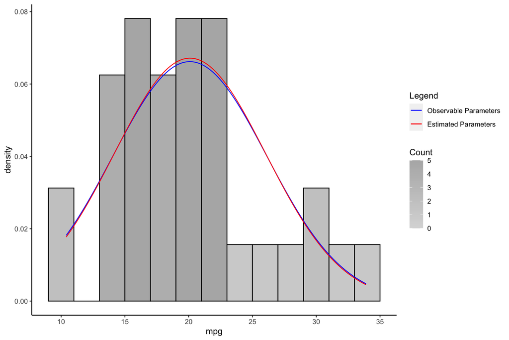

## MLE for the parameters $\beta_0$ and $\beta_1$ in logistic regression

In simple logistic regression, we have a numeric explanatory variable $X$ and binary response variable $Y$ that takes one of two values, 0 (failure) or 1 (success). We suppose that $P(Y=1|X=x) = p(x; \beta_0, \beta_1)$ for some function $p$ of the data $x$ and two parameters $\beta_0$ and $\beta_1$, so that $P(Y=0|X=x) = 1 - p(x; \beta_0, \beta_1)$.

Given the data $(x_1, y_1), \ldots, (x_n, y_n)$, where each $y_i \in \{0, 1\}$, the probability of the data under the model is

$$f(y_1, \ldots, y_n | x_1, \ldots, x_n;
\beta_0, \beta_1) = \prod_{i=1}^n p(x_i; \beta_0, \beta_1)^{y_i} (1 -
p(x_i; \beta_0, \beta_1))^{1-y_i}$$

A *logistic transformation* maps $p \in [0, 1]$ to $\log\left(\frac{p}{1-p}\right)$, whose range is the entire real line. We define $p(x; \beta_0, \beta_1)$ implicitly by requiring its logistic transformation to be linear:

$$\log\left(\frac{p(x; \beta_0,
\beta_1)}{1-p(x; \beta_0, \beta_1)}\right) = \beta_0 + \beta_1
x$$

Solving for $p(x; \beta_0, \beta_1)$ gives

$$p(x; \beta_0, \beta_1) = \frac{1}{1 +
\exp(-(\beta_0 + \beta_1 x))}$$

which is called the sigmoid function.

```r
## Function for p(x;par) where par = c(beta0, beta1)
sigmoid = function(par, x)
{
  return ( 1/(1 + exp(-par[1] - par[2]*x)) )
}
```

The likelihood of $(\beta_1, \beta_1)$ given the data is then

$$L(\beta_0, \beta_1; x_1, \ldots, x_n,
y_1, \ldots, y_n) = \prod_{i=1}^n \left(\frac{1}{1 + \exp(-(\beta_0 +
\beta_1 x_i))}\right)^{y_i} \left(1 - \frac{1}{1 + \exp(-(\beta_0 +
\beta_1 x_i))}\right)^{1-y_i}$$

and the log likelihood is (after a few lines of work)
$$l(\beta_0, \beta_1; x_1, \ldots, x_n, y_1,
\ldots, y_n) = -\sum_{i=1}^n \log(1 + \exp(\beta_0 + \beta_1 x_i)) +
\sum_{i=1}^n y_i (\beta_0 + \beta_1 x_i)$$

```r
Log.Lik = function(par, x, y)
{
  p = sigmoid(par, x)
  return ( -sum(y*log(p) + (1-y)*log(1-p)) )
}
```

Consider the `menarche` data frame in the `MASS` package (`require("MASS"); ?menarche`). It gives proportions of girls at various ages who have reached menarche.

```
## # A tibble: 25 × 3
##      Age Total Menarche
##    <dbl> <dbl>    <dbl>
##  1  9.21   376        0
##  2 10.2    200        0
##  3 10.6     93        0
##  4 10.8    120        2
##  5 11.1     90        2
##  6 11.3     88        5
##  7 11.6    105       10
##  8 11.8    111       17
##  9 12.1    100       16
## 10 12.3     93       29
## # ℹ 15 more rows
```

The first row says “0 out of 376 girls with average age 9.21 have reached menarche.” The tenth row says “29 out of 93 girls with average age 12.33 have reached menarche.” The last row says “1049 out of 1049 girls with average age 17.58 have reached menarche.”

Here I’ll make a second data frame called `menarche.cases` from `menarche` that gives one line for each girl in the study indicating her age and whether (1) or not (0) she has reached menarche.

```r
success.indices = rep(x=seq_len(nrow(menarche)), times=menarche$Menarche)
success.ages = menarche$Age[success.indices]
success = data.frame(age=success.ages, reached.menarche=1)
failure.indices = rep(x=seq_len(nrow(menarche)), times=menarche$Total - menarche$Menarche)
failure.ages = menarche$Age[failure.indices]
failure = data.frame(age=failure.ages, reached.menarche=0)
menarche.cases = rbind(success, failure)
menarche.cases = menarche.cases[order(menarche.cases$age), ]
rownames(menarche.cases) = NULL # Remove incorrectly ordered rownames; they get restored correctly.
menarche.cases
```

```
## # A tibble: 3,918 × 2
##      age reached.menarche
##    <dbl>            <dbl>
##  1  9.21                0
##  2  9.21                0
##  3  9.21                0
##  4  9.21                0
##  5  9.21                0
##  6  9.21                0
##  7  9.21                0
##  8  9.21                0
##  9  9.21                0
## 10  9.21                0
## # ℹ 3,908 more rows
```

### Use `optim()` with its default Nelder-Mead method to find the estimates of $\beta_0$ and $\beta_1$ that maximize $l$ over the data $x_1, \ldots, x_n, y_1, \ldots, y_n =$ `age`, `reached.menarche` from `menarche.cases`. Check your `optim()` estimates by making a graph with these elements:

```r
opt.par = optim(par = c(.5, .5),
                fn = Log.Lik,
                gr = NULL,
                x = menarche.cases$age,
                y = menarche.cases$reached.menarche,
                method = 'Nelder-Mead',
                lower = -Inf,
                upper = Inf)

opt.par
```

```
## $par
## [1] -21.220857   1.631518
##
## $value
## [1] 819.6524
##
## $counts
## function gradient
##      109       NA
##
## $convergence
## [1] 0
##
## $message
## NULL
```

```r
## The 3918 points (x=age, y=reached.menarche) from menarche.cases with jitter
## to create random noise for age
x1 = c(jitter(menarche.cases$age))
y1 = c(menarche.cases$reached.menarche)
id1 = rep('menarche.cases', nrow(menarche.cases))
```

The 25 points $(x_i, y_i)$ where $x_i$ is the $i$th age in the original `menarche` data frame, and $y_i$ is the proportion of girls of that age who have reached menarche.

```r
## 25 points (xi, yi) where xi is the ith age in the original menarche data frame,
## and yi is the proportion of girls of that age who have reached menarche
x2 = c(menarche$Age)
y2 = c()

for (i in 1:nrow(menarche))
{
  y2 = append(y2, 1/menarche[i,]$Total * menarche[i,]$Menarche)
}

id2 = rep('menarch', nrow(menarche))
```

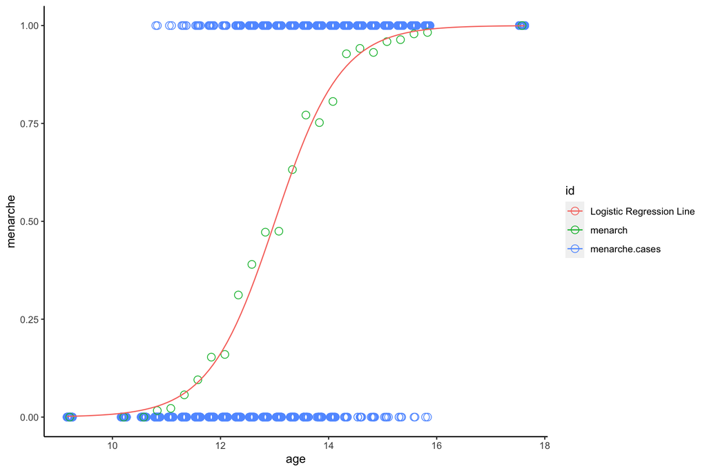